# Mediation Analysis with Multiple Mediators

Christian Testa

March 17, 2021

# Introduction

The following approaches are based on [*Mediation Analysis with Multiple Mediators* by Tyler VanderWeele and Stijn Vansteelandt (2014)](https://www.degruyter.com/document/doi/10.1515/em-2012-0010/html).

Below is the first of two approaches for dealing with multiple mediators: a regression based approach, and a weighting-based approach (not here yet).

## Regression-Based Approach

### Methodology

The example I’ll work below based on a simulated data set will reflect a situation where there are two mediators, one of which has a causal effect on the second.

Considering our set of confounding covariates as $C$, our exposure of interest $A$, our first mediator as $M^{(1)}$, our second mediator as $M^{(2)}$, and our outcome as $Y$, the causal diagram looks like the following:

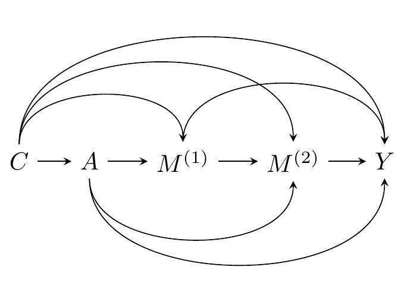

In general, to perform mediation analyses with $K$ mediators where there are no exposure-mediator or mediator-mediator interactions, one estimates the following $K+1$ regression equations:

$$\mathbb E[Y | a, m, c] = \theta_0 + \theta_1 a + \theta_2^{(1)} m^{(1)} +
\cdots + \theta_2^{(K)}m^{(K)} + \theta_4'$$

$$\mathbb E[M^{(i)} | a, c] = \beta_0^{(i)} + \beta_1^{(i)}a + \beta_2^{(i)\prime}c \text{ for } i = 1,\dots,K.$$
Now we can define our controlled direct effect, natural direct effect, and natural indirect effect. Since there are no exposure-mediator interactions, the controlled direct effect and natural direct effect are equivalent.

$$\text{CDE}(m) = \theta_1(a-a^*)$$

$$\text{NDE} = \theta_1(a-a^*)$$

$$\text{NIE} = (\beta_1^1 \theta_2^1 + \dots + \beta_1^k \theta_2^k)(a-a^*)$$
Remember that in order for these values to have a valid causal interpretation, the standard assumptions from causal inference must be true:

1. Conditional on $C$, there is no unmeasured confounding of the exposure-outcome relationship.
2. There is no unmeasured confounding of the mediator outcome relationship conditioning on $A$ and $C$.
3. Conditioning on $C$, there is no unmeasured confounding of the exposure-mediator relationship.
4. There are no mediator-outcome confounders which are affected by the exposure $A$.

In the case of multiple mediators, these assumptions must be true for all of the mediators.

### Simulated Data

Let’s work out an example with simulated data now.

In this example, $M^{(2)}$ will have a causal dependency on both $A$ and $M^{(1)}$. Further, $Y$ will depend on each of $A$, $M^{(1)}$, and $M^{(2)}$ but there will not be any exposure-mediator or mediator-mediator interactions.

For simplicity in these examples, we won’t include confounding covariates $C$.

```r
N <- 1000
A <- rbinom(size = 1, prob = 0.5, n = N)
M1 <- A + rnorm(sd = .25, n = N)
M2 <- -.5*A + 2*M1 + rnorm(sd = .45, n = N)
Y <- .1*A + .3*M1 + .2*M2 + rnorm(sd = .25, n = N)
```

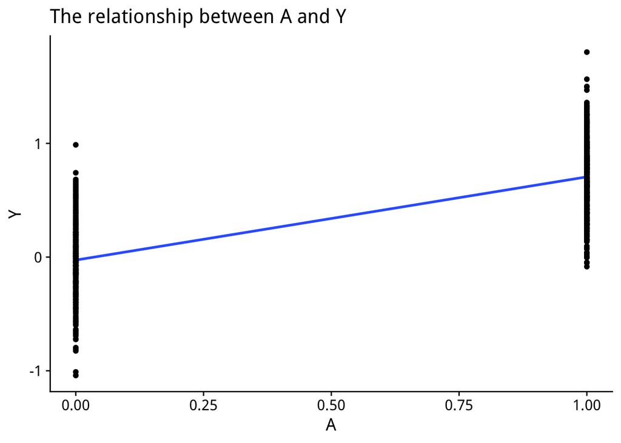

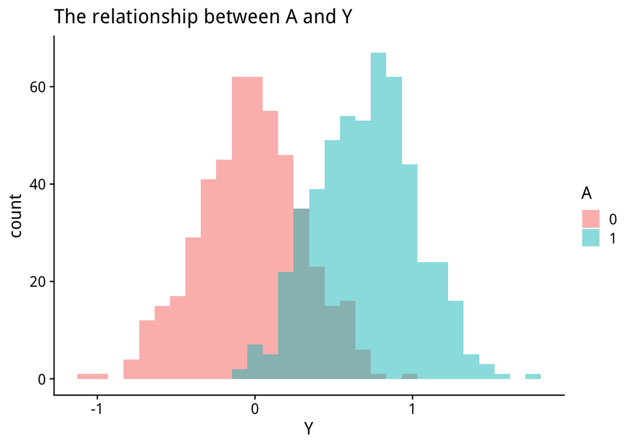

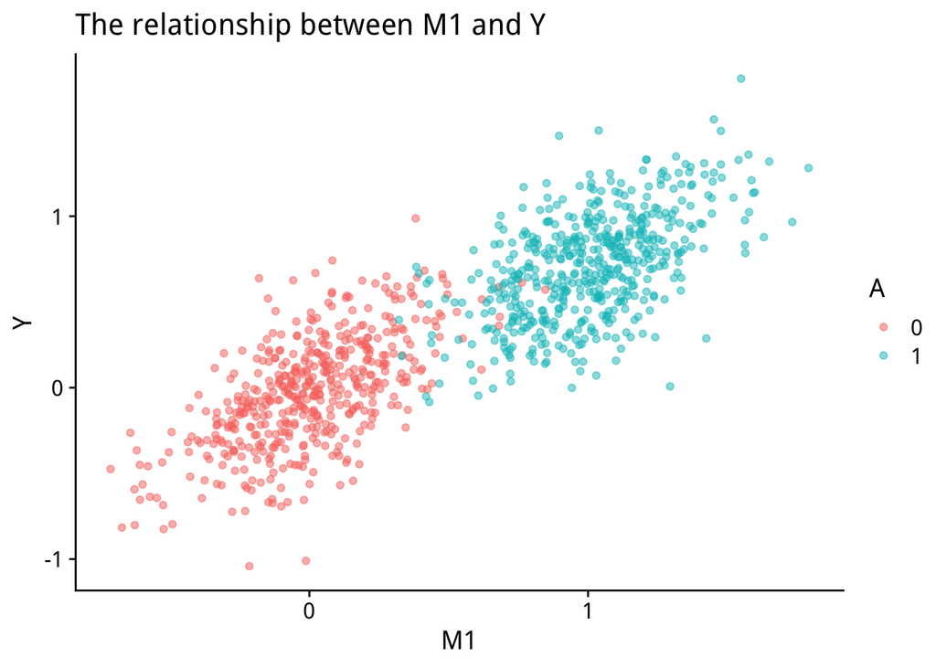

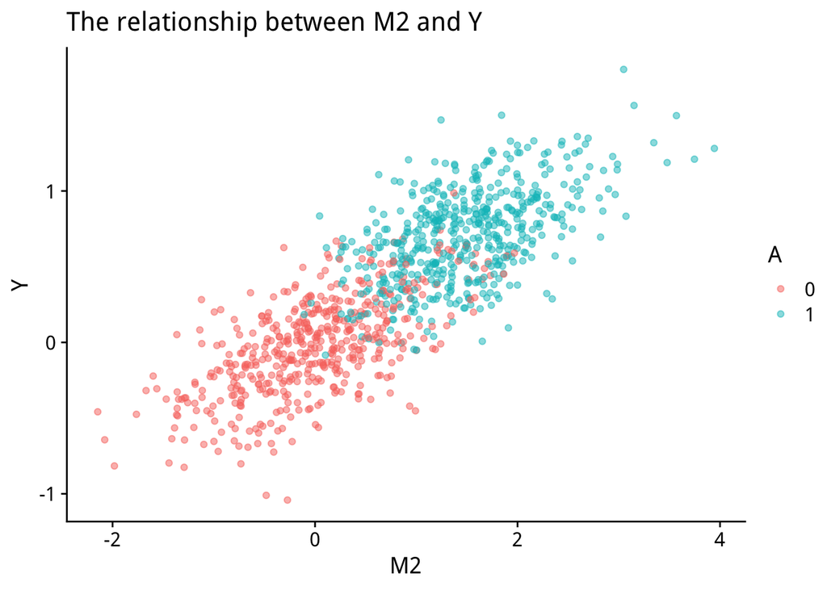

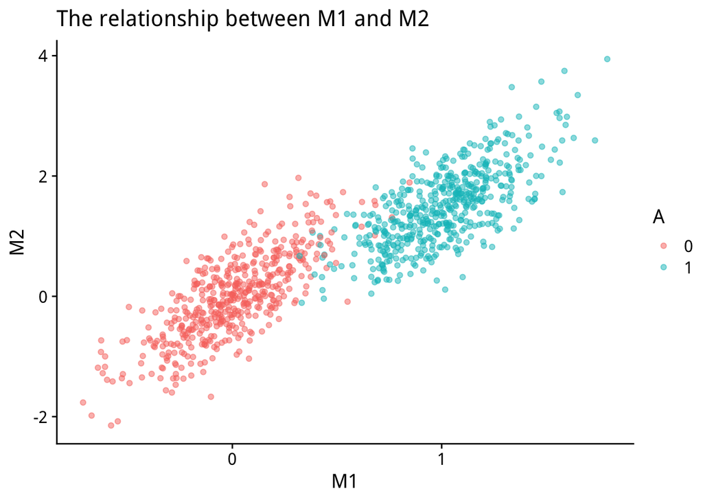

### Mediation Analysis

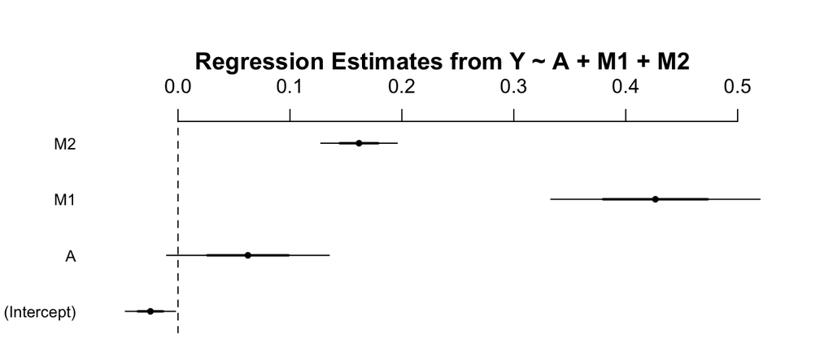

```r
library(broom)
library(tidyverse)

# fit models
Y_model <- lm(Y ~ A + M1 + M2)
M1_model <- lm(M1 ~ A)
M2_model <- lm(M2 ~ A)

# print the coefficients from E[Y|a,m1,m2]
arm::coefplot(Y_model, intercept = TRUE,
              main = "Regression Estimates from Y ~ A + M1 + M2")
```

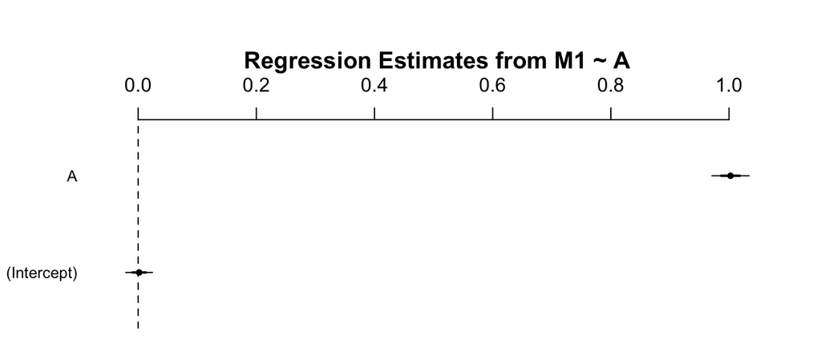

```r
# plot the coefficients from E[M1|a]
arm::coefplot(M1_model, intercept = TRUE,
              main = "Regression Estimates from M1 ~ A")
```

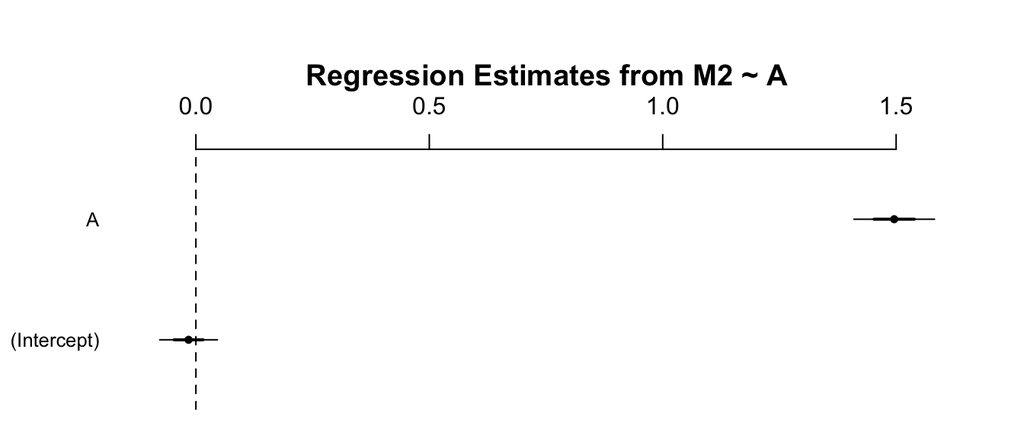

```r
# print the coefficients from E[M2|a]
arm::coefplot(M2_model, intercept = TRUE,
              main = "Regression Estimates from M2 ~ A")
```

```r
# pull out the model coefficients
thetas <- tidy(Y_model)
betas_M1 <- tidy(M1_model)
betas_M2 <- tidy(M2_model)

# Natural Direct Effect
NDE <- thetas %>% filter(term == 'A') %>% pull(estimate)
print(NDE)
```

```
## [1] 0.06244957
```

```r
# Natural Indirect Effect
beta_M1_1 <- betas_M1 %>% filter(term == 'A') %>% pull(estimate)
beta_M2_1 <- betas_M2 %>% filter(term == 'A') %>% pull(estimate)
theta_M1 <- thetas %>% filter(term == 'M1') %>% pull(estimate)
theta_M2 <- thetas %>% filter(term == 'M2') %>% pull(estimate)
NIE_M1 <- beta_M1_1 * theta_M1
NIE_M2 <- beta_M2_1 * theta_M2
print(NIE_M1)
```

```
## [1] 0.4275975
```

```r
print(NIE_M2)
```

```
## [1] 0.2418879
```

```r
NIE <- NIE_M1 + NIE_M2
print(NIE)
```

```
## [1] 0.6694854
```

One of the interesting things about the natural indirect effect with multiple mediators is that we can describe proportionally how much of the natural indirect effects are expressed through each mediator. In this case 64% of the NIE is through $M^{(1)}$ and the remaining 36% is through $M^{(2)}$.

```r
knitr::kable(tidy(lm(Y~A)))
```

| term | estimate | std.error | statistic | p.value |
| --- | --- | --- | --- | --- |
| (Intercept) | -0.0264906 | 0.0144602 | -1.831967 | 0.0672543 |
| A | 0.7319350 | 0.0201890 | 36.254057 | 0.0000000 |

```r
# Total Effect, TE = NIE + NDE
print(NIE + NDE)
```

```
## [1] 0.731935
```

Calculating the total effect in these two ways gives us an opportunity to confirm that they agree as a spot-check for our work. In this case, we can see that the total effect estimated as `NIE + NDE` is exactly the same as the total effect estimated as the coefficient on $A$ in the regression $Y\sim A$.